# forecast_SSI

## 1. Khám phá Dữ liệu (EDA)

Khai báo các thư viện cần sử dụng

```python
import pandas as pd
import numpy as np
from sklearn.model_selection import train_test_split, cross_val_score
from sklearn.ensemble import RandomForestClassifier
from sklearn.metrics import accuracy_score, classification_report
import matplotlib.pyplot as plt
import seaborn as sns
import matplotlib.pyplot as plt
import json
```

```python
# Đọc tệp JSON tải về từ API
with open('response.json', 'r') as file:
    data = json.load(file)

market_data  = pd.DataFrame(data['StockWaveRequest']['stockWaves']['waveDatas'])

market_data ['date'] = pd.to_datetime(market_data ['date'])
```

```python
market_data .head()
```

|  | buy | date | sell | waitbuy | waitsell |
| --- | --- | --- | --- | --- | --- |
| 0 | 6 | 2020-01-06 | 14 | 36 | 25 |
| 1 | 2 | 2020-01-07 | 8 | 45 | 23 |
| 2 | 3 | 2020-01-08 | 17 | 36 | 20 |
| 3 | 9 | 2020-01-09 | 6 | 72 | 18 |
| 4 | 18 | 2020-01-10 | 8 | 54 | 17 |

```python
##market_data .to_csv(f'market_data.csv')
```

```python
# Đọc tập dữ liệu thu thập giá cổ phiểu SSI
ssi_stock_data = pd.read_csv('ssi_stock_data.csv')
```

```python
ssi_stock_data.head()
```

|  | Ngày | Lần cuối | Mở | Cao | Thấp | KL | % Thay đổi |
| --- | --- | --- | --- | --- | --- | --- | --- |
| 0 | 6/8/2024 | 30600.0 | 29600.0 | 31000.0 | 29400.0 | 17.11M | 3.38% |
| 1 | 5/8/2024 | 29600.0 | 30650.0 | 31150.0 | 29500.0 | 22.03M | -5.28% |
| 2 | 2/8/2024 | 31250.0 | 29850.0 | 31350.0 | 29750.0 | 15.35M | 3.14% |
| 3 | 1/8/2024 | 30300.0 | 32100.0 | 32100.0 | 30000.0 | 23.88M | -4.72% |
| 4 | 31/07/2024 | 31800.0 | 32200.0 | 32300.0 | 31700.0 | 7.85M | -0.47% |

```python
# Đổi tên cột
ssi_stock_data.columns = ['date', 'close', 'open','high', 'low', 'volume', 'percent_change']
```

```python
ssi_stock_data['date'] = pd.to_datetime(ssi_stock_data['date'], format='%d/%m/%Y')

# Chuyển đổi ngày sang định dạng YYYY-MM-DD
ssi_stock_data['date'] = ssi_stock_data['date'].dt.strftime('%Y-%m-%d')

print(ssi_stock_data.head())
```

```
         date    close     open     high      low  volume percent_change
0  2024-08-06  30600.0  29600.0  31000.0  29400.0  17.11M          3.38%
1  2024-08-05  29600.0  30650.0  31150.0  29500.0  22.03M         -5.28%
2  2024-08-02  31250.0  29850.0  31350.0  29750.0  15.35M          3.14%
3  2024-08-01  30300.0  32100.0  32100.0  30000.0  23.88M         -4.72%
4  2024-07-31  31800.0  32200.0  32300.0  31700.0   7.85M         -0.47%
```

```python
ssi_stock_data['date'] = pd.to_datetime(ssi_stock_data['date'])
market_data['date'] = pd.to_datetime(market_data['date'])

# Kết hơp 2 tập dữ liệu
df = pd.merge(ssi_stock_data, market_data, on='date')
```

```python
# Xóa giá trị cuối dữ liệu
df['volume'] = df['volume'].str.replace('M','').astype(float)
df['percent_change'] = df['percent_change'].str.replace('%', '').astype(float)
```

```python
df.dtypes
```

```
date              datetime64[ns]
close                    float64
open                     float64
high                     float64
low                      float64
volume                   float64
percent_change           float64
buy                        int64
sell                       int64
waitbuy                    int64
waitsell                   int64
dtype: object
```

```python
df
```

|  | date | close | open | high | low | volume | percent_change | buy | sell | waitbuy | waitsell |
| --- | --- | --- | --- | --- | --- | --- | --- | --- | --- | --- | --- |
| 0 | 2024-08-06 | 30600.0 | 29600.0 | 31000.0 | 29400.0 | 17.11 | 3.38 | 21 | 3 | 229 | 10 |
| 1 | 2024-08-05 | 29600.0 | 30650.0 | 31150.0 | 29500.0 | 22.03 | -5.28 | 3 | 67 | 107 | 10 |
| 2 | 2024-08-02 | 31250.0 | 29850.0 | 31350.0 | 29750.0 | 15.35 | 3.14 | 4 | 4 | 139 | 25 |
| 3 | 2024-08-01 | 30300.0 | 32100.0 | 32100.0 | 30000.0 | 23.88 | -4.72 | 2 | 59 | 41 | 25 |
| 4 | 2024-07-31 | 31800.0 | 32200.0 | 32300.0 | 31700.0 | 7.85 | -0.47 | 13 | 21 | 63 | 61 |
| ... | ... | ... | ... | ... | ... | ... | ... | ... | ... | ... | ... |
| 1140 | 2020-01-10 | 9968.6 | 9805.2 | 9995.8 | 9750.7 | 3.50 | 1.95 | 18 | 8 | 54 | 17 |
| 1141 | 2020-01-09 | 9777.9 | 9777.9 | 9832.4 | 9723.5 | 1.95 | 1.13 | 9 | 6 | 72 | 18 |
| 1142 | 2020-01-08 | 9669.0 | 9832.4 | 9859.7 | 9560.1 | 4.44 | -2.74 | 3 | 17 | 36 | 20 |
| 1143 | 2020-01-07 | 9941.4 | 9914.1 | 9968.6 | 9886.9 | 1.09 | 0.28 | 2 | 8 | 45 | 23 |
| 1144 | 2020-01-06 | 9914.1 | 9886.9 | 9968.6 | 9832.4 | 2.28 | -0.27 | 6 | 14 | 36 | 25 |

1145 rows × 11 columns

```python
# Kiểm tra có giá trị null hay không
df.isnull().sum()
```

```
date              0
close             0
open              0
high              0
low               0
volume            0
percent_change    0
buy               0
sell              0
waitbuy           0
waitsell          0
dtype: int64
```

```python
df.describe()
```

|  | date | close | open | high | low | volume | percent_change | buy | sell | waitbuy | waitsell |
| --- | --- | --- | --- | --- | --- | --- | --- | --- | --- | --- | --- |
| count | 1145 | 1145.000000 | 1145.000000 | 1145.000000 | 1145.000000 | 1145.000000 | 1145.000000 | 1145.000000 | 1145.000000 | 1145.000000 | 1145.000000 |
| mean | 2022-04-21 22:49:34.323144192 | 24574.095721 | 24594.156943 | 25015.375197 | 24171.653100 | 16.641528 | 0.139240 | 16.361572 | 16.439301 | 69.780786 | 74.063755 |
| min | 2020-01-06 00:00:00 | 6264.400000 | 6318.900000 | 6482.300000 | 6046.500000 | 1.090000 | -7.000000 | 0.000000 | 0.000000 | 3.000000 | 6.000000 |
| 25% | 2021-03-02 00:00:00 | 17125.800000 | 17140.100000 | 17606.800000 | 16740.900000 | 9.480000 | -1.230000 | 4.000000 | 5.000000 | 30.000000 | 35.000000 |
| 50% | 2022-04-22 00:00:00 | 23187.100000 | 23187.100000 | 23799.000000 | 22802.300000 | 15.530000 | 0.000000 | 9.000000 | 11.000000 | 53.000000 | 65.000000 |
| 75% | 2023-06-15 00:00:00 | 34391.500000 | 34400.000000 | 34800.000000 | 34000.000000 | 21.960000 | 1.470000 | 19.000000 | 21.000000 | 91.000000 | 103.000000 |
| max | 2024-08-06 00:00:00 | 49668.900000 | 50468.500000 | 51268.200000 | 48869.200000 | 69.560000 | 8.860000 | 224.000000 | 144.000000 | 383.000000 | 258.000000 |
| std | NaN | 10856.004279 | 10888.879602 | 11032.372896 | 10725.707305 | 9.308856 | 2.866294 | 22.448549 | 17.598823 | 56.588040 | 49.254054 |

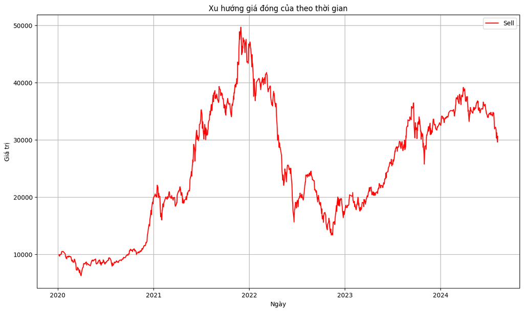

```python
# Vẽ biểu đồ đường cho từng cột
plt.figure(figsize=(14, 8))
plt.plot(df['date'], df['close'], label='Sell', color='red')
plt.title('Xu hướng giá đóng của theo thời gian')
plt.xlabel('Ngày')
plt.ylabel('Giá trị')
plt.legend()
plt.grid(True)
plt.show()
```

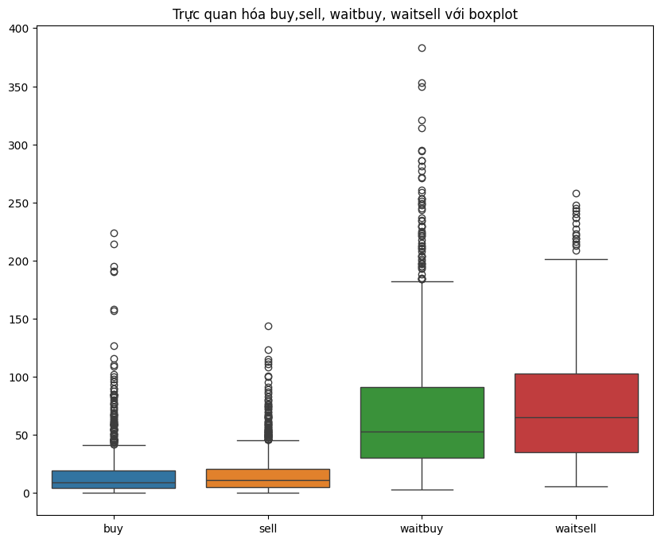

```python
import seaborn as sns
import matplotlib.pyplot as plt

# Trực quan hóa buy,sell, waitbuy, waitsell với boxplot
plt.figure(figsize=(10, 8))
sns.boxplot(data=df[['buy', 'sell', 'waitbuy', 'waitsell']])
plt.title("Trực quan hóa buy,sell, waitbuy, waitsell với boxplot")
plt.show()
```

## 2. Phân tích tương quan

Vẽ biểu đồ tương quan giữa các biến

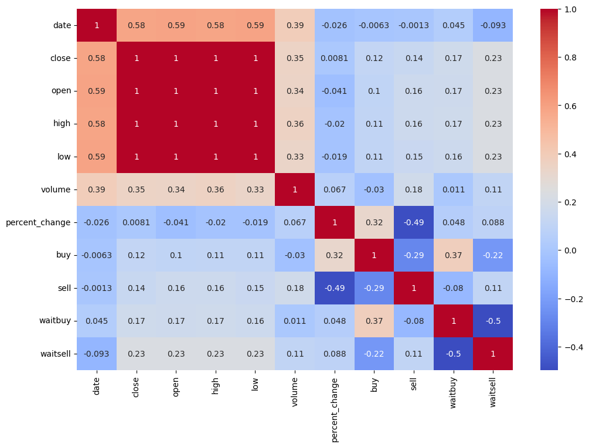

```python
plt.figure(figsize=(12, 8))
sns.heatmap(df.corr(), annot=True, cmap='coolwarm')
plt.show()
```

```python
# In ra bảng giá trị tương quan chuẩn
correlation_matrix = df.corr()
correlation_matrix
```

|  | date | close | open | high | low | volume | percent_change | buy | sell | waitbuy | waitsell |
| --- | --- | --- | --- | --- | --- | --- | --- | --- | --- | --- | --- |
| date | 1.000000 | 0.583546 | 0.585055 | 0.582234 | 0.586212 | 0.388156 | -0.025616 | -0.006255 | -0.001309 | 0.044963 | -0.093038 |
| close | 0.583546 | 1.000000 | 0.998206 | 0.999210 | 0.999104 | 0.346984 | 0.008147 | 0.116054 | 0.138185 | 0.170698 | 0.233149 |
| open | 0.585055 | 0.998206 | 1.000000 | 0.999273 | 0.999246 | 0.342765 | -0.041145 | 0.100697 | 0.162383 | 0.165020 | 0.229979 |
| high | 0.582234 | 0.999210 | 0.999273 | 1.000000 | 0.999019 | 0.355721 | -0.019763 | 0.108594 | 0.158273 | 0.173398 | 0.230794 |
| low | 0.586212 | 0.999104 | 0.999246 | 0.999019 | 1.000000 | 0.333476 | -0.018829 | 0.105857 | 0.145418 | 0.158891 | 0.233737 |
| volume | 0.388156 | 0.346984 | 0.342765 | 0.355721 | 0.333476 | 1.000000 | 0.067044 | -0.030282 | 0.179666 | 0.011225 | 0.107146 |
| percent_change | -0.025616 | 0.008147 | -0.041145 | -0.019763 | -0.018829 | 0.067044 | 1.000000 | 0.317167 | -0.488325 | 0.048193 | 0.087974 |
| buy | -0.006255 | 0.116054 | 0.100697 | 0.108594 | 0.105857 | -0.030282 | 0.317167 | 1.000000 | -0.290733 | 0.374604 | -0.222444 |
| sell | -0.001309 | 0.138185 | 0.162383 | 0.158273 | 0.145418 | 0.179666 | -0.488325 | -0.290733 | 1.000000 | -0.080429 | 0.106684 |
| waitbuy | 0.044963 | 0.170698 | 0.165020 | 0.173398 | 0.158891 | 0.011225 | 0.048193 | 0.374604 | -0.080429 | 1.000000 | -0.497128 |
| waitsell | -0.093038 | 0.233149 | 0.229979 | 0.230794 | 0.233737 | 0.107146 | 0.087974 | -0.222444 | 0.106684 | -0.497128 | 1.000000 |

#### Tương quan giữa các biến số và percent_change (Biến động giá SSI)

- buy: Tương quan dương (0.317) với percent_change. Cho thấy khi số lượng "buy" tăng, giá cổ phiếu SSI có xu hướng tăng. Điều này có thể xem xét là một tín hiệu tích cực cho việc mua vào khi chỉ số "buy" cao.
- sell: Tương quan âm mạnh (-0.488) với percent_change. Khi số lượng "sell" tăng, giá cổ phiếu SSI có xu hướng giảm. Đây là một tín hiệu để xem xét bán ra khi chỉ số "sell" tăng cao.
- waitbuy: Tương quan yếu (0.048) với percent_change. Chỉ số "waitbuy" dường như không có mối quan hệ mạnh với biến động giá SSI, do đó có thể ít được sử dụng trong quyết định giao dịch.
- waitsell: Tương quan dương yếu (0.087), tuy nhiên khi xem xét tương quan giữa waitsell và percent_change thấp, nhưng waitsell lại có tương quan âm với waitbuy (-0.497), cho thấy khi chỉ số "waitsell" tăng, giá cổ phiếu có thể không tăng nhiều hoặc có xu hướng giảm.

#### Nhận xét tương quan giữa các thông số buy, sell, waitbuy, waitsell

- buy và sell: -0.2907. Cho thấy khi tín hiệu mua (buy) tăng lên, tín hiệu bán (sell) có xu hướng giảm. Mối tương quan âm này hợp lý vì khi nhiều người mua vào, số lượng người bán ra thường giảm.
- buy và waitbuy: 0.3746. Cho thấy sự tương quan dương khá mạnh, cho thấy rằng khi tín hiệu chờ mua (waitbuy) tăng, tín hiệu mua (buy) cũng có xu hướng tăng. Điều này có thể giải thích là khi có nhiều tín hiệu chờ mua, các nhà đầu tư có xu hướng chuyển sang hành động mua thực sự.
- buy và waitsell: -0.2224. Đây là một mối tương quan âm, cho thấy rằng khi tín hiệu chờ bán (waitsell) tăng, tín hiệu mua (buy) có xu hướng giảm. Điều này hợp lý vì khi nhiều người chờ bán, số lượng người mua có thể giảm đi.
- sell và waitbuy: -0.0804. Tương quan âm khá nhỏ, cho thấy rằng khi tín hiệu chờ mua (waitbuy) tăng, tín hiệu bán (sell) có xu hướng giảm nhẹ. Tuy nhiên, do mối tương quan này khá yếu, sự ảnh hưởng giữa hai biến số không quá rõ ràng.
- sell và waitsell: 0.1067. Đây là một mối tương quan dương yếu, cho thấy rằng khi tín hiệu chờ bán (waitsell) tăng, tín hiệu bán (sell) cũng có xu hướng tăng. Điều này hợp lý vì khi nhiều người chờ bán, có thể dẫn đến việc nhiều người thực sự bán ra.
- waitbuy và waitsell: -0.4971. Đây là một mối tương quan âm mạnh, cho thấy rằng khi tín hiệu chờ mua (waitbuy) tăng, tín hiệu chờ bán (waitsell) có xu hướng giảm rõ rệt. Điều này hợp lý vì khi nhiều người đang chờ mua, số lượng người chờ bán có thể giảm đi.

## 3. Thuật toán

Sử dụng thuật toán Kmean để phân vùng các giá trị của 4 chỉ số (buy, sell, waitbuy, waitsell) để dự đoán khi nào nên mua vào hay bán ra cổ phiếu SSI.

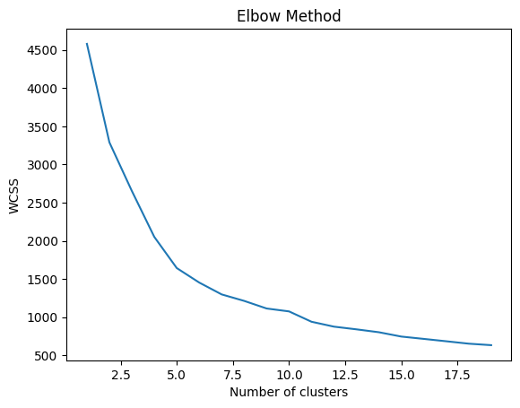

```
        date    close     open     high      low  volume  percent_change  buy  \
0 2024-08-06  30600.0  29600.0  31000.0  29400.0   17.11            3.38   21
1 2024-08-05  29600.0  30650.0  31150.0  29500.0   22.03           -5.28    3
2 2024-08-02  31250.0  29850.0  31350.0  29750.0   15.35            3.14    4
3 2024-08-01  30300.0  32100.0  32100.0  30000.0   23.88           -4.72    2
4 2024-07-31  31800.0  32200.0  32300.0  31700.0    7.85           -0.47   13

   sell  waitbuy  waitsell  cluster
0     3      229        10        0
1    67      107        10        3
2     4      139        25        2
3    59       41        25        3
4    21       63        61        2
```

```python
from sklearn.cluster import KMeans
from sklearn.preprocessing import StandardScaler


data = df[['buy', 'sell', 'waitsell', 'waitbuy']]

# Chuẩn hóa dữ liệu
scaler = StandardScaler()
data_scaled = scaler.fit_transform(data)

# Sử dụng phương pháp Elbow để tìm K tối ưu
wcss = []
for i in range(1, 20):
    kmeans = KMeans(n_clusters=i, init='k-means++', random_state=42)
    kmeans.fit(data_scaled)
    wcss.append(kmeans.inertia_)

plt.plot(range(1, 20), wcss)
plt.title('Elbow Method')
plt.xlabel('Number of clusters')
plt.ylabel('WCSS')
plt.show()

# Chọn K = 4 dựa trên biểu đồ Elbow
kmeans = KMeans(n_clusters=4, init='k-means++', random_state=42)
y_kmeans = kmeans.fit_predict(data_scaled)

# Gán nhãn cụm vào df
df['cluster'] = y_kmeans

print(df.head())
```

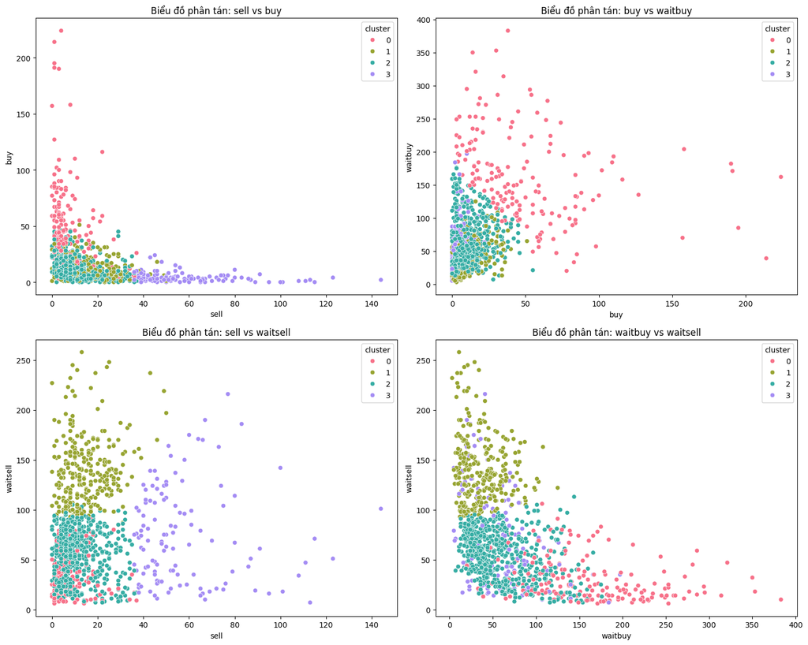

```python
# Vẽ biểu đồ trực quan để đánh giá các cụm

colors = sns.color_palette("husl", 4)
fig, axs = plt.subplots(2, 2, figsize=(15, 12))

# Biểu đồ 1: sell vs buy
sns.scatterplot(ax=axs[0, 0], data=df, x='sell', y='buy', hue='cluster', palette=colors)
axs[0, 0].set_title('Biểu đồ phân tán: sell vs buy')

# Biểu đồ 2: buy vs waitbuy
sns.scatterplot(ax=axs[0, 1], data=df, x='buy', y='waitbuy', hue='cluster', palette=colors)
axs[0, 1].set_title('Biểu đồ phân tán: buy vs waitbuy')

# Biểu đồ 3: sell vs waitsell
sns.scatterplot(ax=axs[1, 0], data=df, x='sell', y='waitsell', hue='cluster', palette=colors)
axs[1, 0].set_title('Biểu đồ phân tán: sell vs waitsell')

# Biểu đồ 4: waitbuy vs waitsell
sns.scatterplot(ax=axs[1, 1], data=df, x='waitbuy', y='waitsell', hue='cluster', palette=colors)
axs[1, 1].set_title('Biểu đồ phân tán: waitbuy vs waitsell')

plt.tight_layout()
plt.show()
```

```python
# Số lượng mỗi cụm
cluster_counts = df['cluster'].value_counts()
print(cluster_counts)
```

```
cluster
2    572
1    283
0    173
3    117
Name: count, dtype: int64
```

#### Nhận xét

- Cụm 0: sell thấp tập trung nhiều ở giá trị 0 - 20, còn buy cao tập trung nhiều trong khoảng 10 - 100, waitbuy cao tập trung nhiều từ 50 - 200, ngược lại waitsell thấp chỉ từ 10 - 80
- Cụm 1: sell tập trung nhiều trong khoảng 0 - 40, buy tập trung trong khoảng 0 -40, nhưng waitsell tập trung nhiều trong khoảng 100 - 200, waitbuy chỉ từ 0 - 90
- Cụm 2: sell tập trung nhiều trong khoảng 0 - 40, buy tập trung trong khoảng 0 -40, nhưng waitbuy tập trung nhiều trong khoảng 10 - 150, waitsell tập trung nhiều khoảng 10 - 100
- Cụm 3: sell cao tập trung nhiều trong khoảng 40 - 120, trong khi đó buy thấp tập trung nhiều trong khoảng 0 - 20, waitsell, waitbuy giá trị trải dài phân bố rộng chứng tỏ ảnh hướng không đáng kể

#### Nhận xét vùng giá trị và đặc điểm của từng cụm, từ đó em đặc tên cho từng cụm như sau:

- Cụm 0: "Mua Mạnh - Bán Yếu"  
  Sell thấp: Tập trung nhiều ở giá trị từ 0 - 20.  
  Buy cao: Tập trung nhiều trong khoảng 10 - 100.  
  Waitbuy cao: Tập trung nhiều từ 50 - 200.  
  Waitsell thấp: Chỉ từ 10 - 80.  
  Cụm này có các đặc điểm cho thấy hoạt động mua vào (buy) mạnh mẽ, trong khi bán ra (sell) yếu, waitbuy cao chứng tỏ sự kỳ vọng mua vào lớn, và waitsell thấp cho thấy ít áp lực bán ra.
- Cụm 1: "Chờ Bán - Mua Yếu"  
  Sell tập trung: Trong khoảng 0 - 40.  
  Buy tập trung: Trong khoảng 0 - 40.  
  Waitsell cao: Tập trung nhiều trong khoảng 100 - 200.  
  Waitbuy thấp: Chỉ từ 0 - 90.  
  Cụm này có xu hướng chờ đợi bán ra với waitsell cao, trong khi mua vào (buy) khá yếu và waitbuy thấp, cho thấy ít mong đợi về sự tăng giá.
- Cụm 2: "Chờ Cơ Hội - Thị Trường Bình Ổn"  
  Sell tập trung: Trong khoảng 0 - 40.  
  Buy tập trung: Trong khoảng 0 - 40.  
  Waitbuy trung bình: Tập trung nhiều trong khoảng 10 - 150.  
  Waitsell trung bình: Tập trung nhiều trong khoảng 10 - 100.  
  Cụm này cho thấy thị trường ổn định với cả hai chỉ số waitbuy và waitsell đều ở mức trung bình, thể hiện sự chờ đợi cơ hội mà không có hành động mạnh mẽ từ phía nhà đầu tư.
- Cụm 3: "Bán Mạnh - Mua Yếu"  
  Sell cao: Tập trung nhiều trong khoảng 40 - 120.  
  Buy thấp: Tập trung nhiều trong khoảng 0 - 20.  
  Waitsell, waitbuy trải dài: Giá trị phân bố rộng, ảnh hưởng không đáng kể.  
  Cụm này cho thấy hoạt động bán ra mạnh mẽ với chỉ số sell cao, trong khi mua vào (buy) yếu, waitsell, waitbuy trải dài không có xu hướng rõ ràng.

Demo dữ liệu mới thuộc nhóm nào

```python
cluster_names = {
    0: 'Mua Mạnh - Bán Yếu',
    1: 'Chờ Bán - Mua Yếu',
    2: 'Chờ Cơ Hội - Thị Trường Bình Ổn',
    3: 'Bán Mạnh - Mua Yếu'
}

# Hàm dự đoán
def predict_cluster(buy, sell, waitbuy, waitsell):

    new_data = pd.DataFrame([[buy, sell, waitsell, waitbuy]], columns=['buy', 'sell', 'waitsell', 'waitbuy'])

    new_data_scaled = scaler.transform(new_data)

    cluster = kmeans.predict(new_data_scaled)[0]

    return cluster_names[cluster]

# Ví dụ: Dự đoán cụm cho một điểm dữ liệu mới như sau:
new_buy = 100
new_sell = 10
new_waitbuy = 100
new_waitsell = 20

predicted_cluster = predict_cluster(new_buy, new_sell, new_waitbuy, new_waitsell)
print(f'Với điểm dữ liệu này bạn nên: {predicted_cluster}')
```

```
Với điểm dữ liệu này bạn nên: Mua Mạnh - Bán Yếu
```

Sử dụng Logistic Regression và Random Forest để dự báo và tối ưu hóa chiến lược giao dịch cho cổ phiếu SSI trong ngày

```python
from sklearn.model_selection import train_test_split
from sklearn.preprocessing import StandardScaler

# Giả sử biến mục tiêu là `target` (ví dụ: nếu `percent_change` > 0 thì 1 nghĩa là giá tăng, ngược lại 0 nghĩa là giá giảm)
df['target'] = (df['percent_change'] > 0).astype(int)

# Chọn các biến đặc trưng
features = ['buy', 'sell', 'waitbuy', 'waitsell']
X = df[features]
y = df['target']

# Chia dữ liệu thành tập huấn luyện và tập kiểm tra
X_train, X_test, y_train, y_test = train_test_split(X, y, test_size=0.3, random_state=42)

# Chuẩn hóa dữ liệu
scaler = StandardScaler()
X_train_scaled = scaler.fit_transform(X_train)
X_test_scaled = scaler.transform(X_test)
```

```python
from sklearn.linear_model import LogisticRegression
from sklearn.metrics import classification_report, accuracy_score

# Tạo mô hình Logistic Regression
logreg = LogisticRegression()
logreg.fit(X_train_scaled, y_train)

# Dự đoán trên tập kiểm tra
y_pred_logreg = logreg.predict(X_test_scaled)

print("Logistic Regression Classification Report:")
print(classification_report(y_test, y_pred_logreg))
print(f"Accuracy: {accuracy_score(y_test, y_pred_logreg)}")
```

```
Logistic Regression Classification Report:
              precision    recall  f1-score   support

           0       0.74      0.57      0.64       178
           1       0.63      0.79      0.70       166

    accuracy                           0.67       344
   macro avg       0.69      0.68      0.67       344
weighted avg       0.69      0.67      0.67       344

Accuracy: 0.6744186046511628
```

```python
from sklearn.ensemble import RandomForestClassifier

# Tạo mô hình Random Forest
rf = RandomForestClassifier(n_estimators=100, random_state=42)
rf.fit(X_train_scaled, y_train)

# Dự đoán trên tập test
y_pred_rf = rf.predict(X_test_scaled)

print("Random Forest Classification Report:")
print(classification_report(y_test, y_pred_rf))
print(f"Accuracy: {accuracy_score(y_test, y_pred_rf)}")
```

```
Random Forest Classification Report:
              precision    recall  f1-score   support

           0       0.67      0.70      0.68       178
           1       0.66      0.63      0.64       166

    accuracy                           0.67       344
   macro avg       0.67      0.66      0.66       344
weighted avg       0.67      0.67      0.67       344

Accuracy: 0.6656976744186046
```

```python
# Dựa trên dự đoán của mô hình, có thể tối ưu hóa chiến lược giao dịch.
# Ví dụ: nếu xác suất tăng giá (dự đoán) > 0.5, có thể quyết định mua vào.

# Dự đoán xác suất với Logistic Regression và Random Forest
y_prob_logreg = logreg.predict_proba(X_test_scaled)[:, 1]

y_prob_rf = rf.predict_proba(X_test_scaled)[:, 1]

# Ví dụ: Quyết định mua vào nếu xác suất dự đoán của Logistic Regression > 0.5
buy_signal_logreg = y_prob_logreg > 0.5
buy_signal_rf = y_prob_rf > 0.5

print("Logistic Regression Buy Signal:")
print(buy_signal_logreg)

print("Random Forest Buy Signal:")
print(buy_signal_rf)
```

[output not shown]